# Using R Markdown (long version)

Daniel McDonald for Booth 41911

22 September, 2018

# Overview

R Markdown is a low-overhead way of writing reports which includes R code and the code’s automatically-generated output. It also lets you include nicely-typeset math, hyperlinks, images, and some basic formatting. The goal of this document is to explain, with examples, how to use its most essential features. It is *not* a comprehensive reference. (See rather http://rmarkdown.rstudio.com.)

This guide assumes that you know at least some R.

This guide is a modification of [Cosma’s](http://www.stat.cmu.edu/~cshalizi/rmarkdown/rmarkdown.Rmd).

# Mark Up, Markdown

You are probably used to word processing programs, like Microsoft Word, which employ the “what you see is what you get” (WYSIWYG) principle: you want some words to be printed in italics, and, lo, they’re in italics right there on the screen. You want some to be in a bigger, different font and you just select the font, and so on. This works well enough for n00bs but is not a viable basis for a system of text formatting, because it depends on a particular program (a) knowing what you mean and (b) implementing it well. For several decades, really serious systems for writing have been based on a very different principle, that of *marking up* text. The essential idea in a **mark-up language** is that it consists of ordinary text, *plus* signs which indicate how to change the formatting or meaning of the text. Some mark-up languages, like HTML (Hyper-Text Markup Language) use very obtrusive markup; others, like the language called **Markdown**, are more subtle. For instance, the last few sentences in Markdown look like this:

```
For several decades, really serious systems for writing have been based on a
very different principle, that of _marking up_ text.  The essential idea in a
**mark-up language** is that it consists of ordinary text, _plus_ signs which
indicate how to change the formatting or meaning of the text.  Some mark-up
languages, like HTML (Hyper-Text Markup Language) use very obtrusive markup;
others, like the language called **Markdown**, are more subtle.
```

Every mark-up language needs to be **rendered** somehow into a format which actually includes the fancy formatting, images, mathematics, computer code, etc., etc., specified by the mark-up. For HTML, the rendering program is called a “web browswer”. Most computers which know how to work with Markdown at all know how to render it as HTML (which you can then view in a browser), PDF (which you can then view in Acrobat or the like), or Word (which you can then view in the abomination of Redmond).

The advantages of mark-up languages are many: they tend to be more portable across machines, less beholden to particular software companies, and more stable over time than WYSIWYG word processing programs. R Markdown is, in particular, both “free as in beer” (you will never pay a dollar for software to use it) and “free as in speech” (the specification is completely open to all to inspect). Even if you are completely OK with making obeisance to the Abomination of Redmond every time you want to read your own words, the sheer stability of mark-up languages makes them superior for scientific documents.

[**Markdown**](http://daringfireball.net/projects/markdown/basics) is a low-overhead mark-up language invented by John Gruber. There are now many programs for translating documents written in Markdown into documents in HTML, PDF or even Word format (among others). [**R Markdown**](http://rmarkdown.rstudio.com) is an extension of Markdown to incorporate running code, in R, and including its output in the document. This document look in turn at three aspects of R Markdown: how to include basic formatting; how to include R code and its output; and how to include mathematics.

# Rendering and Editing

To write R Markdown, you will need a text editor, a program which lets you read and write plain text files. You will also need R, and the package `rmarkdown` (and all the packages it depends on).

- Most computers come with a text editor (TextEdit on the Mac, Notepad on Windows machines, etc.).
- There are also lots of higher-powered text editors; I use [Emacs](http://www.gnu.org/software/emacs/emacs.html), but I admit it has a harsh learning curve.
- You *could* use Word (or some other WYSIWYG word processor), taking care to always save your document in plain text format. I do not recommend this.
- [R Studio](http://www.rstudio.com) comes with a built-in text editor, which knows about, and has lots of tools for, working with R Markdown documents.

If this is your first time using a text editor for something serious, I recommend using R Studio.

### Rendering in R Studio

Assuming you have the document you’re working on open in the text editor, click the button that says “knit”.

# Basic Formatting in R Markdown

For the most part, text is just text. One advantage of R Markdown is that the vast majority of your document will be stuff you just type as you ordinarily would.

### Paragraph Breaks and Forced Line Breaks

To insert a break between paragraphs, include a single completely blank line.

To force a line break, put *two*  
blank spaces at the end of a line.

### Headers

The character `#` at the beginning of a line means that the rest of the line is interpreted as a section header. The number of `#`s at the beginning of the line indicates whether it is treated as a section, sub-section, sub-sub-section, etc. of the document. For instance, `Basic Formatting in R Markdown` above is preceded by a single `#`, but `Headers` at the start of this paragraph was preceded by `###`. Do not interrupt these headers by line-breaks.

### Italics, Boldface

Text to be *italicized* goes inside *a single set of underscores* or *asterisks*. Text to be **boldfaced** goes inside a **double set of underscores** or **asterisks**.

### Quotations

Set-off quoted paragraphs are indicated by an initial `>`:

> In fact, all epistemological value of the theory of probability is based on this: that large-scale random phenomena in their collective action create strict, nonrandom regularity. [Gnedenko and Kolmogorov, *Limit Distributions for Sums of Independent Random Variables*, p. 1]

### Computer Type

Text to be printed in a fixed-width font, without further interpretation, goes in paired left-single-quotes, a.k.a. “back-ticks”, without line breaks in your typing. If you want to display multiple lines like this, start them with three back ticks in a row on a line by themselves, and end them the same way:

```
`Text to be printed in a fixed-width font, without further interpretation,
goes in paired left-single-quotes, a.k.a. "back-ticks", without line breaks
in your typing.`
```

### Bullet Lists

- This is a list marked where items are marked with bullet points.
- Each item in the list should start with a `*` (asterisk) character.
- Each item should also be on a new line.
  - Indent lines and begin them with `+` for sub-bullets.
  - Sub-sub-bullet aren’t really a thing in R Markdown.

### Numbered lists

1. Lines which begin with a numeral (0–9), followed by a period, will usually be interpreted as items in a numbered list.
2. R Markdown handles the numbering in what it renders automatically.
3. This can be handy when you lose count or don’t update the numbers yourself when editing. (Look carefully at the .Rmd file for this item.)
   1. Sub-lists of numbered lists, with letters for sub-items, are a thing.
   2. They are however a fragile thing, which you’d better not push too hard.

### Title, Author, Date, Output Format

You can specify things like title, author and date in the **header** of your R Markdown file. This goes at the very beginning of the file, preceded and followed by lines containing three dashes. Thus the beginning of this file looks like so:

```
---
title: Using R Markdown for Class Reports
author: DM
date: Last revised 11 January 2015
---
```

```
---
title: Using R Markdown for Class Reports
author: DM
date: Last revised 11 January 2015
output: pdf_document
---
```

- To create PDF, a program called `LaTeX` (see below) has to be installed on your computer.
- Other output formats may be available. See `help(render)` in the `rmarkdown` package.
- There are many, many other formatting options which can be given in the header; see the main R Markdown help files online.
- This header information is called `YAML` if you need the [Google](http://www.google.com).

# Hyperlinks and Images

### Hyperlinks

Hyperlinks anchored by URLs are easy: just type the URL, as, e.g., http://mypage.iu.edu/~dajmcdon/ to get to my website

Hyperlinks anchored to text have the [anchor in square brackets, then the link in parentheses](https://xkcd.com/1521/).

A very useful link is the [R markdown cheatsheet](https://www.rstudio.com/wp-content/uploads/2015/02/rmarkdown-cheatsheet.pdf).

### Images

Images begin with an exclamation mark, then the text to use if the image can’t be displayed, then either the file address of the image (in the same directory as your document) or a URL. The example below is for a url.

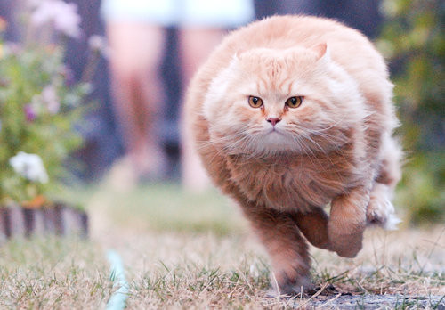

A remote image

(If there’s a way of re-sizing images like this in Markdown, I haven’t been able to find it.)

# Including Code

The real point of R Markdown is that it lets you include your code, have the code run automatically when your document is rendered, and seemlessly include the results of that code in your document. The code comes in two varieties, code **chunks** and **inline** code.

### Code Chunks and Their Results

A code **chunk** is simply an off-set piece of code by itself. It is preceded by `` ```{r} `` on a line by itself, and ended by a line which just says `` ``` ``. The code itself goes in between. Here, for instance, is some code which loads a data set from a library, and makes a scatter plot.

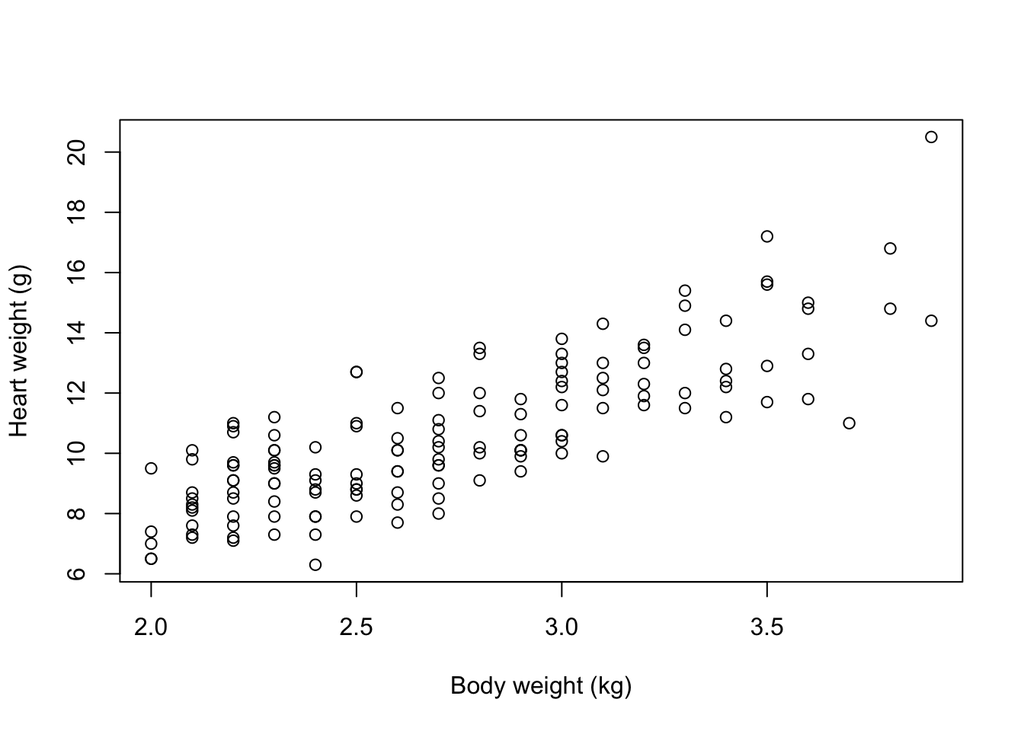

First, notice how the code is included, nicely formatted, in the document. Second, notice how the output of the code is also automatically included in the document. If your code outputs numbers or text, those can be included too:

```
## [1] 0.8041274
```

### Inline Code

Code output can also be seamlessly incorporated into the text, using **inline code**. This is code not set off on a line by itself, but beginning with `` `r `` and ending with `` ` ``. Using inline code is how this document knows that the `cats` data set contains 144 rows, and that the median weight of the female cats’ hearts was 9.1 grams.

Notice that inline code does *not* display the commands run, just their output.

### Seen But Not Heard

Code chunks (but not inline code) can take a lot of **options** which modify how they are run, and how they appear in the document. These options go after the initial `r` and before the closing `}` that announces the start of a code chunk. One of the most common options turns off printing out the code, but leaves the results alone: `` ```{r, echo=FALSE} ``

Another runs the code, but includes neither the text of the code nor its output. `` ```{r, include=FALSE} `` This might seem pointless, but it can be useful for code chunks which do set-up like loading data files, or initial model estimates, etc.

Another option prints the code in the document, but does not run it: `` ```{r, eval=FALSE} `` This is useful if you want to talk about the (nicely formatted) code.

### Naming Chunks

You can give chunks names immediately after their opening, like `` ```{r clevername} ``. This name is then used for the images (or other files) that are generated when the document is rendered.

### Changing Image Sizes and Alignments

There are a bunch of options for adjusting the placement of the figures which R produces. `fig.align` controls the horizontal **alignment** (left, right, or center).

When producing PDF, the options `out.height` and `out.width` let you specify the desired height or width of the figure, in inches, centimeters, or multiples of pre-defined lengths (from `LaTeX`). So for instance `` ```{r, out.height="3in"} `` forces the image to be 3 inches high, while `` ```{r, out.width="0.48\\textwidth"} `` forces the image’s width to be a bit less than half of the total width of the text on the page (so that two such images will fit side by side). The next few figures illustrate.

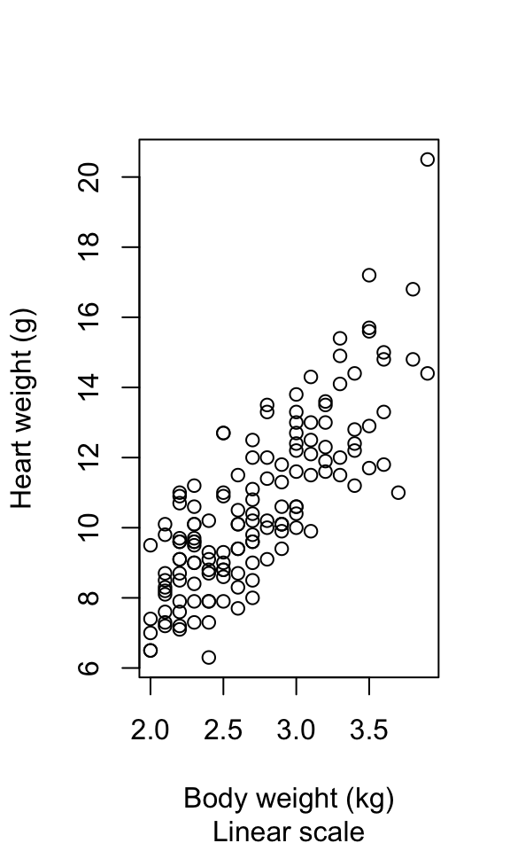

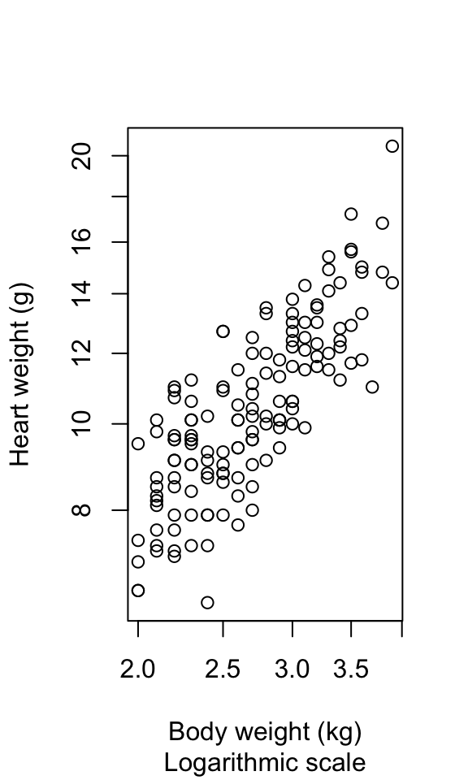

### Tables

The default print-out of matrices, tables, etc. from R Markdown is frankly ugly. The `knitr` package contains a very basic command, `kable`, which will format an array or data frame more nicely for display.

Compare:

```
##               Estimate Std. Error    t value     Pr(>|t|)
## (Intercept) -0.3566624  0.6922770 -0.5152019 6.072131e-01
## Bwt          4.0340627  0.2502615 16.1193908 6.969045e-34
```

with

|  | Estimate | Std. Error | t value | Pr(>\|t\|) |
| --- | --- | --- | --- | --- |
| (Intercept) | -0.3566624 | 0.6922770 | -0.5152019 | 0.6072131 |
| Bwt | 4.0340627 | 0.2502615 | 16.1193908 | 0.0000000 |

For producing PDFs, I also like

This will like gobbledygook in HTML, but `LaTeX` will handle it properly. `xtable` works as well. Sometimes you will need to include the `results='asis'` option if you output tables to pdf (more below).

— Of course, R’s defaults print out a crazy number of decimal places. So use

|  | Estimate | Std. Error | t value | Pr(>\|t\|) |
| --- | --- | --- | --- | --- |
| (Intercept) | -0.357 | 0.692 | -0.515 | 0.607 |
| Bwt | 4.034 | 0.250 | 16.119 | 0.000 |

### “Caching” Code Chunks (Re-Running Only When Changed)

By default, R Markdown will re-run all of your code every time you render your document. If some of your code is slow, this can add up to a lot of time. You can, however, ask R Markdown to keep track of whether a chunk of code has changed, and only re-run it if it has. This is called **caching** the chunk.

```
##
## Call:
## lm(formula = Hwt ~ Bwt, data = cats)
##
## Coefficients:
## (Intercept)          Bwt
##     -0.3567       4.0341
```

One issue is that a chunk of code which hasn’t changed itself might call on results of earlier, modified chunks, and then we *would* want to re-run the downstream chunks. There are options for manually telling R Markdown “this chunk depends on this earlier chunk”, but it’s generally easier to let it take care of that, by setting the `autodep=TRUE` option.

1. If you load a package with the `library()` or `require()` commands, R Markdown isn’t smart enough to check whether the package has changed (or indeed been installed, if you were missing it). So that won’t trigger an automatic re-running of a cached code chunk.
2. To manually force re-running all code chunks, the easiest thing to do is to delete the directory R Markdown will create (named something like *filename*`_cache`) which it uses to store the state of all code chunks.

### Setting Defaults for All Chunks

You can tell R to set some defaults to apply to all chunks where you don’t specifically over-ride them. Here are the ones I generally use:

This sets some additional options beyond the ones I’ve discussed, like not re-running a chunk if only the comments have changed (`cache.comments = FALSE`), and leaving out messages and warnings.

You can over-ride these defaults by setting options for individual chunks.

### More Options

See http://yihui.name/knitr/options/ for a complete listing of possible chunk options.

# Math in R Markdown

**Point out the [Cheat sheet](https://www.rstudio.com/wp-content/uploads/2015/02/rmarkdown-cheatsheet.pdf).**

Since this is a statistics class, you need to be able to write out mathematical expressions, often long series of them. R Markdown gives you the syntax to render complex mathematical formulas and derivations, and have them displayed *very* nicely. Like code, the math can either be inline or set off (**displays**).

Inline math is marked off with a pair of dollar signs (`$`), as $\pi r^2$ or $e^{i\pi}$.

What about an actual $?

Mathematical displays are marked off with `\[` and `\]`, as in
$$e^{i \pi} = -1$$

Once your text has entered math mode, R Markdown turns over the job of converting your text into math to a different program, called LaTeX[^1]. This is the most common system for typesetting mathematical documents throughout the sciences, and has been for decades. It is extremely powerful, stable, available on basically every computer, and completely free. It is also, in its full power, pretty complicated. Fortunately, the most useful bits, for our purposes, are actually rather straightforward.

### Elements of Math Mode

- Most letters will be rendered in italics (compare: a vs. `a` vs. $a$; only the last is in math mode). The spacing between letters also follows the conventions for math, so don’t treat it as just another way of getting italics. (Compare *speed*, in simple italics, with $speed$, in math mode.)
- Greek letters can be accessed with the slash in front of their names, as `\alpha` for $\alpha$. Making the first letter upper case gives the upper-case letter, as in `\Gamma` for $\Gamma$ vs. `\gamma` for $\gamma$. (Upper-case alpha and beta are the same as Roman A and B, so no special commands for them.)
- There are other “slashed” (or “escaped”) commands for other mathematical symbols:
  - `\times` for $\times$
  - `\cdot` for $\cdot$
  - `\leq` and `\geq` for $\leq$ and $\geq$
  - `\subset` and `\subseteq` for $\subset$ and $\subseteq$
  - `\leftarrow`, `\rightarrow`, `\Leftarrow`, `\Rightarrow` for $\leftarrow$, $\rightarrow$, $\Leftarrow$, $\Rightarrow$
  - `\approx`, `\sim`, `\equiv` for $\approx$, $\sim$, $\equiv$
  - See, e.g., http://web.ift.uib.no/Teori/KURS/WRK/TeX/symALL.html for a fuller listing of available symbols. (http://tug.ctan.org/info/symbols/comprehensive/symbols-a4.pdf lists *all* symbols available in `LaTeX`, including many non-mathematical special chracters)
- Subscripts go after an underscore character, `_`, and superscripts go after a caret, `^`, as `\beta_1` for $\beta_1$ or `a^2` for $a^2$.
- Curly braces are used to create groupings that should be kept together, e.g., `a_{ij}` for $a_{ij}$ (vs. `a_ij` for $a_ij$).
- If you need something set in ordinary (Roman) type within math mode, use `\mathrm`, as `t_{\mathrm{in}}^2` for $t_{\mathrm{in}}^2$.
- If you’d like something set in an outline font (“blackboard bold”), use `\mathbb`, as `\mathbb{R}` for $\mathbb{R}$.
- For bold face, use `\mathbf`, as
  $$(\mathbf{x}^\top \mathbf{x})^{-1}\mathbf{x}^\top \mathbf{y}$$
- Accents on characters work rather like changes of font: `\vec{a}` produces $\vec{a}$, `\hat{a}` produces $\hat{a}$. Some accents, particularly hats, work better if they space out, as with `\widehat{\mathrm{Var}}` producing $\widehat{\mathrm{Var}}$.
- Function names are typically written in romans, and spaced differently: thus $\log{x}$, not $log x$. `LaTeX`, and therefore `R Markdown`, knows about a lot of such functions, and their names all begin with `\`. For instance: `\log`, `\sin`, `\cos`, `\exp`, `\min`, etc. Follow these function names with the argument in curly braces; this helps `LaTeX` figure out what exactly the argument is, and keep it grouped together with the function name when it’s laying out the text. Thus `\log{(x+1)}` is better than `\log (x+1)`.
- Fractions can be created with `\frac`, like so:
  $$\frac{a+b}{b} = 1 + \frac{a}{b}$$
- Sums can be written like so:
  $$\sum_{i=1}^{n}{x_i^2}$$
  The lower and upper limits of summation after the `\sum` are both optional. Products and integrals work similarly, only with `\prod` and `\int`:
  $$n! = \prod_{i=1}^{n}{i}$$
  $$\log{b} - \log{a} = \int_{x=a}^{x=b}{\frac{1}{x} dx}$$
  `\sum`, `\prod` and `\int` all automatically adjust to the size of the expression being summed, producted or integrated.
- “Delimiters”, like parentheses or braces, can automatically re-size to match what they’re surrounding. To do this, you need to use `\left` and `\right`, as

$$\left( \sum_{i=1}^{n}{i} \right)^2 = \left( \frac{n(n-1)}{2}\right)^2 = \frac{n^2(n-1)^2}{4}$$
+ To use curly braces as delimiters, precede them with slashes, as `\{` and `\}` for $\{$ and $\}$. * Multiple equations, with their equals signs lined up, can be created using `aligned`, as follows.

$$\begin{equation}
\begin{aligned}
X & \sim \mathrm{N}(0,1)\\
Y & \sim \chi^2_{n-p}\\
R & \equiv X/Y \sim t_{n-p}
\end{aligned}
\end{equation}$$

Notice that `&` surrounds what goes in the middle on each line, and each line (except the last) is terminated with `\\`. The left or right hand side of the equation can be blank, and space will be made:

$$\begin{equation}
\begin{aligned}
P(|X-\mu| > k) & = P(|X-\mu|^2 > k^2)\\
& \leq \frac{\mathbb{E}\left[|X-\mu|^2\right]}{k^2}\\
& \leq \frac{\mathrm{Var}[X]}{k^2}
\end{aligned}
\end{equation}$$

(In full `LaTeX`, `\begin{eqnarray}` automatically enters math mode, that is, no need for `\[` and `\]`, but R Markdown to HTML needs the hint.)

### Translating Math into `LaTeX`

`LaTeX` is designed so that every part of a mathematical expression has a reasonably straightforward counterpart in what you write. Still, it can be a bit intimidating at first. What many people find useful to to start by taking some page of printed or hand-written math and then deliberately translate that, line by line, into `LaTeX`, and then rendering it to see whether it came out right (and, if not, where to fix things). If you need to do any math for an assignment, it can be a good idea to write the math out by hand, and then turn it into `LaTeX`, whether the class requires it (like this one) or not. Eventually, with practice, the translation will become quite automatic, and some people even do new math by writing out the `LaTeX`.

### `LaTeX` Does Not Check Correctness

`LaTeX` does not check whether your math is *right*; it just checks whether it can figure out what you’re trying to say well enough to type-set it. Thus for instance it has no problem at all with the following:

$$\begin{equation}
\begin{aligned}
(n+1)(n-1) & = n^2\\
n^2 -1 & = n^2\\
-1 & = 0\\
1 & = 0\\
-1 & = 1
\end{aligned}
\end{equation}$$

### More Advanced Math-Mode Stuff: New Commands

One of the things you can do in `LaTeX` is create your own commands. This is useful if you find yourself writing out the same complicated expression repeatedly, or, alternatively, if you want to make sure that the same symbol is always used for the same concept. For instance, in some areas of statistics, the generic parameter of a model is $\theta$, in others $\beta$, in yet others $\psi$. If you do something like this early on

```
\[
\newcommand{\MyParameter}{\theta}
\]
```

then in later bits of math mode you can write `\MyParameter`, and `LaTeX` will translate this to `\theta`. If you later decide that you want your parameter to be `\beta`, or even `\mathrm{fred}`, you just change that initial definition of the new command, rather than having to track down each `\theta`.

New commands can also take one or more arguments. Here is a useful command for writing expectations:

```
\[
\newcommand{\Expect}[1]{\mathbb{E}\left[ #1 \right]}
\]
```

And here is a command for writing covariances:

```
\[
\newcommand{\Cov}[2]{\mathrm{Cov}\left[ #1, #2\right]}
\]
```

Defining commands like this not only saves you typing, and makes it easier to make changes; it also makes your math-mode text easier for you, or others, to read even if it isn’t rendered. This is like using comprehensible variable and function names in your programs, and for that matter like using functions rather than long strings of commands in the first place.

It is also possible to define new function names which act like `\log`, new mathematical operators, draw diagrams, etc., etc., but that goes way beyond the scope of these notes.

I usually make a single document that has all of these things in it and *load* it at the beginning of my document like

```
---
title: Using R Markdown for Class Reports
author: DM
date: Last revised 11 January 2015
output: pdf_document:
  includes:
    in_header: 432macros.tex
---
```

This document looks like

```
\usepackage{amsthm}

\DeclareMathOperator*{\argmin}{argmin}
\DeclareMathOperator*{\argmax}{argmax}


\newcommand{\X}{\mathbf{X}}
\newcommand{\Y}{\mathbf{Y}}
\newcommand{\Ident}{\mathbf{I}}
\newcommand{\HatMat}{\mathbf{H}}
\renewcommand{\hat}[1]{\widehat{#1}}
\newcommand{\Expect}[1]{\mathbb{E}\left[ #1 \right]}
\newcommand{\Var}[1]{\mathrm{Var}\left[ #1 \right]}
\newcommand{\Cov}[1]{\mathrm{Cov}\left[ #1 \right]}
\newcommand{\Prob}[1]{\mathbb{P}\left( #1 \right)}
\newcommand{\R}{\mathbb{R}}
\newcommand{\tr}{\textrm{trace}}

\newcommand{\norm}[1]{\lVert #1 \rVert}
```

### Installing `LaTeX`

If you render your R Markdown document to HTML, you do not need to install `LaTeX` on your computer. This is because the HTML includes instructions to browsers, which say (as it were) “Send the funny-looking bits with all the slashes to mathjax.org, and it will send you back pretty pictures of equations”. The website actually runs the `LaTeX`.

If you want to produce PDF, you need to have `LaTeX` installed on your computer. How you actually do this depends on the precise kind of computer. For Macs, I recommend using the `MacTeX` package, available from https://tug.org/mactex/mactex-download.html. For other systems, follow the links from http://www.tug.org/begin.html.

# Putting It All Together: Writing Your Report in R Markdown

- You have installed the `rmarkdown` package and all its dependencies.
- You have installed `LaTeX`, if you’re producing a PDF.
- You have installed and fired up your favorite text editor.
- You open it up to a new document.
  - You give it a title, an author, and a date.
- You use headers to divide it into appropriate, titled sections, and possibly sub-sections.
  - One common pattern: “Introduction”, “Data and Research Questions”, “Analysis”, “Results”, “Conclusion”.
  - Another common pattern: “Problem 1”, “Problem 2”, … , “Extra Credit”.
- You write text.
- When you need it, you insert math into the text, or even whole mathematical displays.
- When you need it, you insert code into your document.
  - The code runs (as needed) when you render the document.
  - Figures, tables, and other output are automatically inserted into the document, and track changes in your code.
- Every so often, try to render your document.
  - When you (think you) have finished a section is a good time to do so.
  - Another good time is once you’ve made any non-trivial change to the code or the text.
- Either your document rendered successfully or it didn’t.
  - If it did, and you like the results, congratulate yourself and cheerfully go on to your next task.
  - If it rendered but you don’t like the results, think about why and try to fix it.
  - If it didn’t render, R will tell you where it gave up, so try to debug from around there.

# Further Reading

For more on R Markdown, see http://rmarkdown.rstudio.com, particularly the more detailed help pages (rather than the first-guides).

For `LaTeX`, the classic reference is the book by Leslie Lamport, *LaTeX: A Document Preparation System* (2nd ed., Reading, Mass.: Addison-Wesley, 1994). This is not, admittedly, the easiest read in the world. [*LaTeX*](https://en.wikibooks.org/wiki/LaTeX), from Wikibooks, is more accessible, and free online in easy bite-sized chunks.

R Markdown is based on the `knitr` package, developed by Yihui Xie, for integrated R with `LaTeX`; see http://yihui.name/knitr/, and, for full documentation, Xie’s book *Dynamic Documents with R and knitr* (2nd edition, Boca Raton, Florida; CRC Press, 2015).

For an thorough, entertaining, and completely correct explanation of why “The word processor is a stupid and grossly inefficient tool for preparing text for communication with others”, see http://ricardo.ecn.wfu.edu/~cottrell/wp.html.

[^1]: In the 1970s, the great computer scientist Donald Knuth wrote a mark-up language, and a rendering program for that language, called `TeX` (pronounced “tech”), for writing complex mathematical documents. In the 1980s, the computer scientist Leslie Lamport extended `TeX` in ways that made it rather more user-friendly, and called the result `LaTeX` (pronounced “la-tech”).